# RDA for Sound analysis

В. М. Хайтов

2023-07-21

```r
library(readxl)
library(vegan)
library(dplyr)
```

```r
library(ggplot2)
```

Файл BD.csv я преобразовал в экселевский файл. Поскольку там везде очень небольшие выборки, то правильнее будет укрупнить градации факторов. В связи с этим предлагаю оставить в качестве градаций времени суток только Day vs Night. Вместо многочисленных месяцев сделать просто четыре сезона (Summer, Autumn, Winter, Spring).

Кстати, почему больше всего наблюдений зимой?

```r
dat <- read_excel("Short_observation.xlsx")

sound <- dat %>% select(Ins, Anur, Bird, Mam, Wind, Rain, Noise)

sound_perc <- decostand(x = sound, MARGIN = 1, method = "total") #Выражаем в представленность источников звука в долях.

predictors <- dat %>% select(Indx, Month_, Day_Part_, Year_Part_, Day_Night)
```

Вот модель для RDA в новой редакции.

```r
Mod <- rda(sound ~ Day_Night + Year_Part_, data = predictors)
```

Ниже приводятся результаты пермутационной оценки значимости самой модели, ее канонических осей и предикторов, включенных в модель.

```r
anova(Mod)
```

```
## Permutation test for rda under reduced model
## Permutation: free
## Number of permutations: 999
##
## Model: rda(formula = sound ~ Day_Night + Year_Part_, data = predictors)
##          Df Variance      F Pr(>F)
## Model     4    83.64 5.1865  0.001 ***
## Residual 95   382.98
## ---
## Signif. codes:  0 '***' 0.001 '**' 0.01 '*' 0.05 '.' 0.1 ' ' 1
```

```r
anova(Mod, by = "axis")
```

```
## Permutation test for rda under reduced model
## Forward tests for axes
## Permutation: free
## Number of permutations: 999
##
## Model: rda(formula = sound ~ Day_Night + Year_Part_, data = predictors)
##          Df Variance       F Pr(>F)
## RDA1      1    42.14 10.4521  0.002 **
## RDA2      1    35.95  8.9181  0.002 **
## RDA3      1     2.97  0.7370  0.854
## RDA4      1     2.58  0.6390  0.620
## Residual 95   382.98
## ---
## Signif. codes:  0 '***' 0.001 '**' 0.01 '*' 0.05 '.' 0.1 ' ' 1
```

```r
anova(Mod, by = "margin")
```

```
## Permutation test for rda under reduced model
## Marginal effects of terms
## Permutation: free
## Number of permutations: 999
##
## Model: rda(formula = sound ~ Day_Night + Year_Part_, data = predictors)
##            Df Variance      F Pr(>F)
## Day_Night   1    40.24 9.9809  0.001 ***
## Year_Part_  3    44.45 3.6753  0.001 ***
## Residual   95   382.98
## ---
## Signif. codes:  0 '***' 0.001 '**' 0.01 '*' 0.05 '.' 0.1 ' ' 1
```

Модель сама по себе значимая. Значимы в ней первые две канонические оси. Все предикторы, тоже влияют на структуру “сообщества”.

Вот summary от этой модели.

```r
summary(Mod)
```

```
##
## Call:
## rda(formula = sound ~ Day_Night + Year_Part_, data = predictors)
##
## Partitioning of variance:
##               Inertia Proportion
## Total          466.62     1.0000
## Constrained     83.64     0.1792
## Unconstrained  382.98     0.8208
##
## Eigenvalues, and their contribution to the variance
##
## Importance of components:
##                          RDA1     RDA2     RDA3    RDA4      PC1     PC2
## Eigenvalue            42.1366 35.95225 2.971055 2.57591 184.9684 90.6665
## Proportion Explained   0.0903  0.07705 0.006367 0.00552   0.3964  0.1943
## Cumulative Proportion  0.0903  0.16735 0.173718 0.17924   0.5756  0.7699
##                            PC3      PC4      PC5     PC6     PC7
## Eigenvalue            45.23457 28.40581 21.20816 6.86448 5.63472
## Proportion Explained   0.09694  0.06088  0.04545 0.01471 0.01208
## Cumulative Proportion  0.86689  0.92776  0.97321 0.98792 1.00000
##
## Accumulated constrained eigenvalues
## Importance of components:
##                          RDA1    RDA2    RDA3   RDA4
## Eigenvalue            42.1366 35.9523 2.97106 2.5759
## Proportion Explained   0.5038  0.4299 0.03552 0.0308
## Cumulative Proportion  0.5038  0.9337 0.96920 1.0000
##
## Scaling 2 for species and site scores
## * Species are scaled proportional to eigenvalues
## * Sites are unscaled: weighted dispersion equal on all dimensions
## * General scaling constant of scores:  14.66052
##
##
## Species scores
##
##          RDA1    RDA2      RDA3     RDA4       PC1      PC2
## Ins    0.6686  3.6784 -0.098147 -0.05325 -7.970784 -3.24019
## Anur  -0.8910  0.8109 -0.810313  0.34827 -0.576198  0.42105
```

[output cut: 220 more lines]

```
## Day_NightNight   -0.9588  0.08023  0.2644 -0.06614   0   0
## Year_Part_Spring  0.2628  0.67858  0.6349  0.25960   0   0
## Year_Part_Summer  0.1355  0.23029 -0.1357 -0.95404   0   0
## Year_Part_Winter -0.2079 -0.95476  0.2117 -0.01994   0   0
##
##
## Centroids for factor constraints
##
##                     RDA1    RDA2    RDA3     RDA4 PC1 PC2
## Day_NightDay      1.4056 -0.1176 -0.3876  0.09696   0   0
## Day_NightNight   -1.4056  0.1176  0.3876 -0.09696   0   0
## Year_Part_Autumn -0.3122  1.0246 -2.6599  0.96968   0   0
## Year_Part_Spring  0.6856  1.7703  1.6563  0.67725   0   0
## Year_Part_Summer  0.7862  1.3363 -0.7877 -5.53608   0   0
## Year_Part_Winter -0.2988 -1.3720  0.3042 -0.02866   0   0
```

Из всего summary принципиально важной является информация только о том, что первые две канонические оси описывают 16.7% суммарной дисперсии. Это не так много, но и сама система состоит из не очень сильно взаимосвязанных компонентов (источников звука).

Поскольку статистически значимыми являются только первые две канонические оси, то попытаемся дать им трактовку. Для этого смотрим на визуализацию RDA.

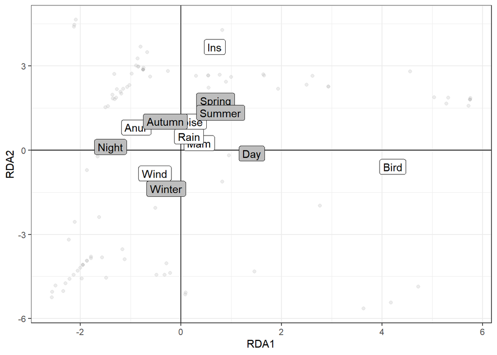

```r
library(ggvegan)
theme_set(theme_bw())

Mod_scores <- fortify(Mod)


species <- Mod_scores %>% filter(Score == "species")
observations <- Mod_scores %>% filter(Score == "sites")
centroids <- Mod_scores %>% filter(Score == "centroids")

centroids$Label2 <- c("Day", "Night", "Autumn", "Spring", "Summer", "Winter")

ggplot(species, aes(x = RDA1, y = RDA2)) +
  geom_vline(xintercept = 0) +
  geom_hline(yintercept = 0) +
  geom_point(data = observations, alpha = 0.3, color = "gray")+
  geom_label(aes(label = Label)) +
  geom_label(data = centroids, aes(label = Label2), fill = "gray")
```

Первая каноническая ось (она описывает больше всего суммарной дисперсии, 9.03%) имеет явную связь с градиентом Day-Night. Максимальные нагрузки по этой оси имеют птицы (максимальная положительная) и лягушки (максимальная отрицательная). Для демонстрации этой связи можно привести вот такие картинки.

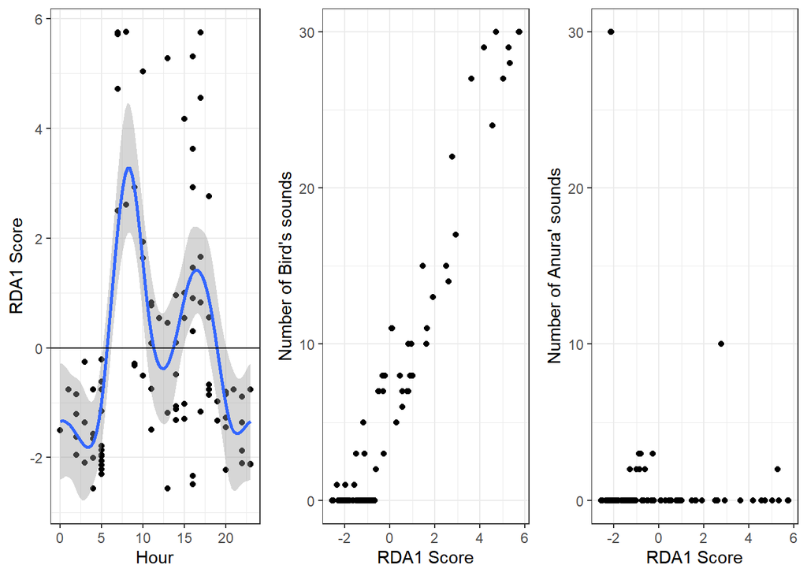

```r
library(cowplot)

Pl_rda1_dynamics <-
  qplot(x = dat$time24, y = observations$RDA1) +
  geom_smooth(method = "gam", formula = y ~ s(x, bs = "cc")) +
  labs(x = "Hour", y = "RDA1 Score") +
  geom_hline(yintercept = 0)
Pl_bird <-
  qplot(x = observations$RDA1, y = dat$Bird) +
  labs(x = "RDA1 Score", y = "Number of Bird's sounds")


Pl_anur <-
  qplot(x = observations$RDA1, y = dat$Anur) +
  labs(x = "RDA1 Score", y = "Number of Anura' sounds")

plot_grid(Pl_rda1_dynamics, Pl_bird, Pl_anur, nrow =1)
```

Вторая каноническая ось явно коррелирует с временами года. Самые высокие нагрузки у насекомых (положительные) и ветра (отрицательные). То есть насекомые больше звучат, когда не зима, а ветра больше, когда зима.

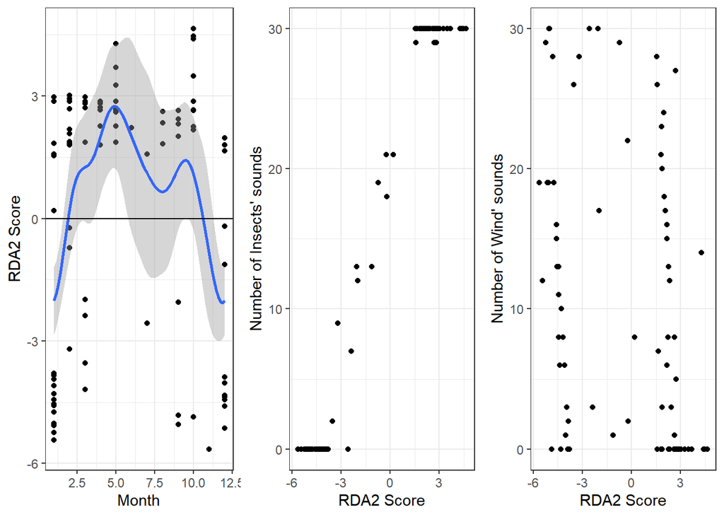

```r
Pl_rda2_dynamics <-
  qplot(x = dat$Month2, y = observations$RDA2) +
  geom_smooth(method = "gam", formula = y ~ s(x, bs = "cc")) +
  labs(x = "Month", y = "RDA2 Score") +
  geom_hline(yintercept = 0)

Pl_ins <-
  qplot(x = observations$RDA2, y = dat$Ins) +
  labs(x = "RDA2 Score", y = "Number of Insects' sounds")


Pl_wind <-
  qplot(x = observations$RDA2, y = dat$Wind) +
  labs(x = "RDA2 Score", y = "Number of Wind' sounds")

plot_grid(Pl_rda2_dynamics, Pl_ins, Pl_wind, nrow =1)
```

При этом насекомые не очень связаны с временем суток.